# Assignment 3

# F2019027004

# Muhammad Abdullah Shahid

```python
import re
import string
import scipy
import pickle
import numpy as np
import pandas as pd
import matplotlib.pyplot as plt
from sklearn.feature_extraction.text import *
from sklearn import preprocessing
from sklearn.preprocessing import LabelEncoder
from sklearn.metrics import accuracy_score
from sklearn.metrics import mean_squared_error
from sklearn.metrics import mean_squared_error
from IPython.display import Markdown, display
import import_ipynb
from prettytable import PrettyTable
from tabulate import tabulate
from astropy.table import Table, Column
```

# Train Data

```
    We have a CSV file which contain some sample and through this data we will train our model.
So first we get data from CSV file and store this data in Pandas.DataFrame by using pandas labirary.
And than we will analyze and do some preprocessing tasks on our train data and represent data through charts for better understanding.
```

```python
trainData = pd.read_csv("train.csv")

pd.options.display.float_format = '{:,.2f}'.format

print("\nTrain data from 'train.csv' file! \n")
print(trainData)
```

```
Train data from 'train.csv' file!

   height  weight    hair beard scarf  gender
0  180.30     196    Bald   Yes    No    Male
1  170.00     120    Long    No    No  Female
2  178.50     200   Short    No    No    Male
3  163.40     110  Medium    No   Yes  Female
4  175.22     220   Short   Yes    No    Male
5  165.00     150  Medium    No   Yes  Female
```

```python
trainData.dtypes
```

```
height    float64
weight      int64
hair       object
beard      object
scarf      object
gender     object
dtype: object
```

```python
print("\nAttributes or Columns from our Train Data! \n")

print(trainData.columns)
```

```
Attributes or Columns from our Train Data!

Index(['height', 'weight', 'hair', 'beard', 'scarf', 'gender'], dtype='object')
```

```python
print("\nTotal observation or records or instances that are prasent in our Train Data: \n")
print(len(trainData.index))
```

```
Total observation or records or instances that are prasent in our Train Data:

6
```

```python
print("\nTrain Data Have ",len(trainData[trainData.gender.isin(['Female'])]), " Female Instances: \n")

print(trainData[trainData.gender.isin(['Female'])])
```

```
Train Data Have  3  Female Instances:

   height  weight    hair beard scarf  gender
1  170.00     120    Long    No    No  Female
3  163.40     110  Medium    No   Yes  Female
5  165.00     150  Medium    No   Yes  Female
```

```python
print("\nTrain Data Have ",len(trainData[trainData.gender.isin(['Male'])]), " Male Instances: \n")

print(trainData[trainData.gender.isin(['Male'])])
```

```
Train Data Have  3  Male Instances:

   height  weight   hair beard scarf gender
0  180.30     196   Bald   Yes    No   Male
2  178.50     200  Short    No    No   Male
4  175.22     220  Short   Yes    No   Male
```

```
Representation of Gender Attribute through Bar Chat for better Understanding:

AxesSubplot(0.125,0.125;0.775x0.755)
```

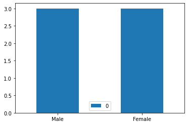

```python
gender = pd.DataFrame( [
            len(trainData[trainData.gender.isin(['Female'])]),
            len(trainData[trainData.gender.isin(['Male'])])
    ], index=["Male", "Female"])

print("\nRepresentation of Gender Attribute through Bar Chat for better Understanding: \n")
print(gender.plot.bar(rot=0))
```

```
Representation of Gender Attribute through Pai Chat for better Understanding:

[<AxesSubplot:ylabel='0'>]
```

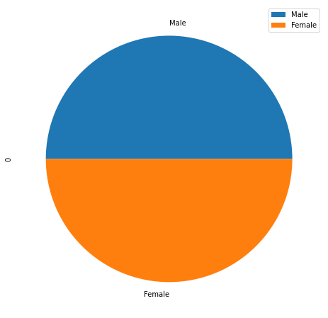

```python
print("\nRepresentation of Gender Attribute through Pai Chat for better Understanding: \n")
print(gender.plot.pie(subplots=True, figsize=(8, 8)))
```

```
Representation of Hair Attribute through Bar Chat for better Understanding:

AxesSubplot(0.125,0.125;0.775x0.755)
```

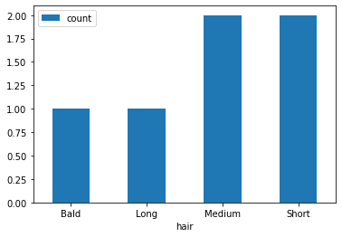

```python
barView = pd.DataFrame(trainData.hair)
barView["count"]= 0

print("\nRepresentation of Hair Attribute through Bar Chat for better Understanding: \n")
print(barView.groupby('hair').count().plot.bar(rot=0))
```

```
Representation of Hair Attribute through Pai Chat for better Understanding:

[<AxesSubplot:ylabel='count'>]
```

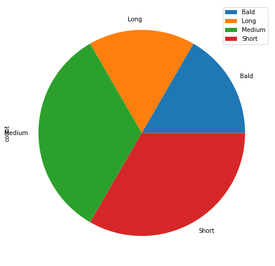

```python
print("\nRepresentation of Hair Attribute through Pai Chat for better Understanding: \n")
print(barView.groupby('hair').count().plot.pie(subplots=True, figsize=(8, 8)))
```

```
Representation of Beard Attribute through bar Chat for better Understanding:

AxesSubplot(0.125,0.125;0.775x0.755)
```

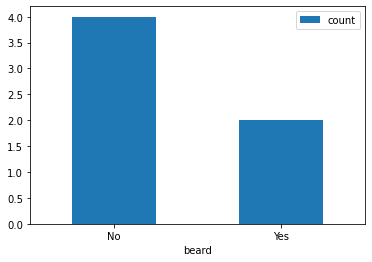

```python
barView = pd.DataFrame(trainData.beard)
barView["count"]= 0

print("\nRepresentation of Beard Attribute through bar Chat for better Understanding: \n")
print(barView.groupby('beard').count().plot.bar(rot=0))
```

```
Representation of Beard Attribute through Pai Chat for better Understanding:

[<AxesSubplot:ylabel='count'>]
```

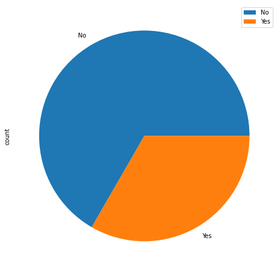

```python
print("\nRepresentation of Beard Attribute through Pai Chat for better Understanding: \n")
print(barView.groupby('beard').count().plot.pie(subplots=True, figsize=(8, 8)))
```

```
Representation of Scarf Attribute through Bar Chat for better Understanding:

AxesSubplot(0.125,0.125;0.775x0.755)
```

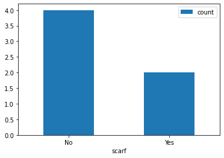

```python
barView = pd.DataFrame(trainData.scarf)
barView["count"]= 0

print("\nRepresentation of Scarf Attribute through Bar Chat for better Understanding:  \n")
print(barView.groupby('scarf').count().plot.bar(rot=0))
```

```
Representation of Scarf Attribute through Pai Chat for better Understanding:

[<AxesSubplot:ylabel='count'>]
```

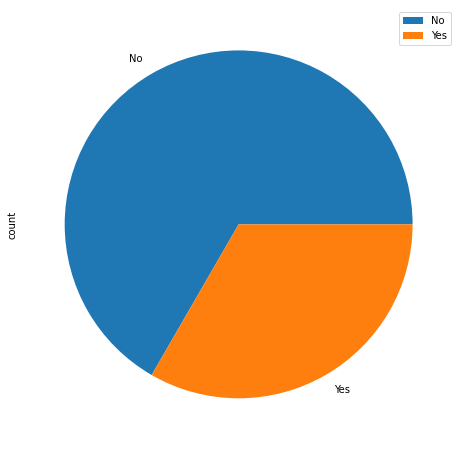

```python
print("\nRepresentation of Scarf Attribute through Pai Chat for better Understanding: \n")
print(barView.groupby('scarf').count().plot.pie(subplots=True, figsize=(8, 8)))
```

```
Representation of Height and Weight Attribute through Bar Chat for better Understanding:

AxesSubplot(0.125,0.125;0.775x0.755)
```

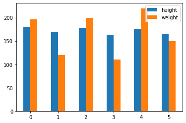

```python
barView = pd.DataFrame(trainData[["height","weight"]])

print("\nRepresentation of Height and Weight Attribute through Bar Chat for better Understanding: \n")
print(barView.plot.bar(rot=0))
```

```
Representation of Height and Weight Attribute through Pai Chat for better Understanding:

[<AxesSubplot:ylabel='height'> <AxesSubplot:ylabel='weight'>]
```

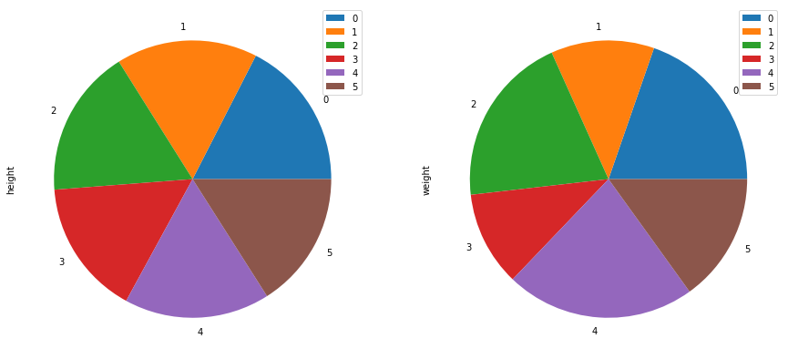

```python
print("\nRepresentation of Height and Weight Attribute through Pai Chat for better Understanding: \n")
print(barView.plot.pie(subplots=True, figsize=(15, 15)))
```

# Test Data

```
    We have a CSV file which contain some sample Test and through this Test data we will test our model.
So first we get data from CSV file and store this data in Pandas.DataFrame by using pandas labirary.
And than we will analyze and do some preprocessing tasks on our test data and represent data through charts for better     understanding.
```

```python
testData = pd.read_csv("test.csv")

print("\nTest data from 'test.csv' file! \n")
print(testData)
```

```
Test data from 'test.csv' file!

   height  weight    hair beard scarf  gender
0  179.10     185    Long   Yes    No    Male
1  160.50     130   Short    No    No  Female
2  177.80     160    Bald    No    No    Male
3  161.10     100  Medium    No    No  Female
```

```python
print("\nAttributes or Columns from our Test Data! \n")
testData.columns
```

```
Attributes or Columns from our Test Data!
```

```
Index(['height', 'weight', 'hair', 'beard', 'scarf', 'gender'], dtype='object')
```

```python
print("\nTotal observation or records or instances that are prasent in our Test Data: \n")
print(len(testData.index))
```

```
Total observation or records or instances that are prasent in our Test Data:

4
```

```python
print("\nTest Data Have ",len(testData[testData.gender.isin(['Female'])]), " Female Instances: \n")
print(testData[testData.gender.isin(['Female'])])
```

```
Test Data Have  2  Female Instances:

   height  weight    hair beard scarf  gender
1  160.50     130   Short    No    No  Female
3  161.10     100  Medium    No    No  Female
```

```python
print("\nTest Data Have ",len(testData[testData.gender.isin(['Male'])]), " Male Instances: \n")
print(testData[testData.gender.isin(['Male'])])
```

```
Test Data Have  2  Male Instances:

   height  weight  hair beard scarf gender
0  179.10     185  Long   Yes    No   Male
2  177.80     160  Bald    No    No   Male
```

```
Representation of Gender Attribute through Bar Chat for better Understanding:

AxesSubplot(0.125,0.125;0.775x0.755)
```

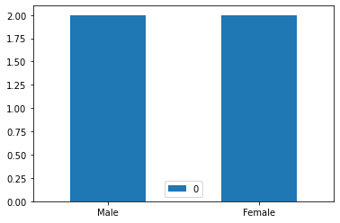

```python
gender = pd.DataFrame( [
            len(testData[testData.gender.isin(['Female'])]),
            len(testData[testData.gender.isin(['Male'])])
    ], index=["Male", "Female"])

print("\nRepresentation of Gender Attribute through Bar Chat for better Understanding: \n")
print(gender.plot.bar(rot=0))
```

```
Representation of Gender Attribute through Pai Chat for better Understanding:

[<AxesSubplot:ylabel='0'>]
```

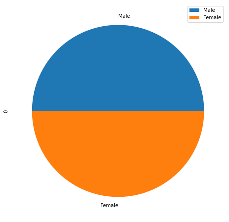

```python
print("\nRepresentation of Gender Attribute through Pai Chat for better Understanding: \n")
print(gender.plot.pie(subplots=True, figsize=(8, 8)))
```

```
Representation of Hair Attribute through Bar Chat for better Understanding:

AxesSubplot(0.125,0.125;0.775x0.755)
```

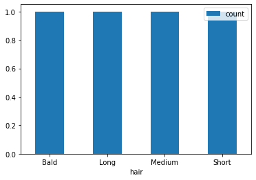

```python
barView = pd.DataFrame(testData.hair)
barView["count"]= 0

print("\nRepresentation of Hair Attribute through Bar Chat for better Understanding: \n")
print(barView.groupby('hair').count().plot.bar(rot=0))
```

```
Representation of Hair Attribute through Pai Chat for better Understanding:

[<AxesSubplot:ylabel='count'>]
```

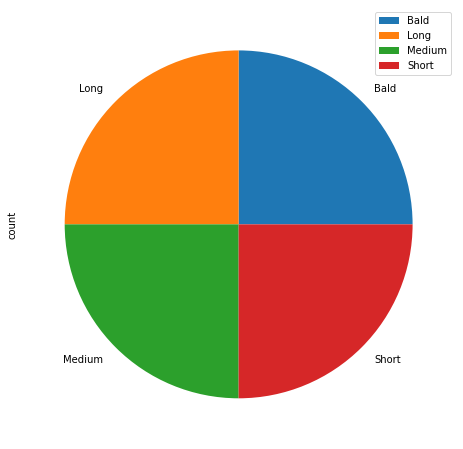

```python
print("\nRepresentation of Hair Attribute through Pai Chat for better Understanding: \n")
print(barView.groupby('hair').count().plot.pie(subplots=True, figsize=(8, 8)))
```

```
Representation of Beard Attribute through bar Chat for better Understanding:

AxesSubplot(0.125,0.125;0.775x0.755)
```

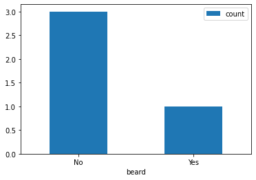

```python
barView = pd.DataFrame(testData.beard)
barView["count"]= 0

print("\nRepresentation of Beard Attribute through bar Chat for better Understanding: \n")
print(barView.groupby('beard').count().plot.bar(rot=0))
```

```
Representation of Beard Attribute through Pai Chat for better Understanding:

[<AxesSubplot:ylabel='count'>]
```

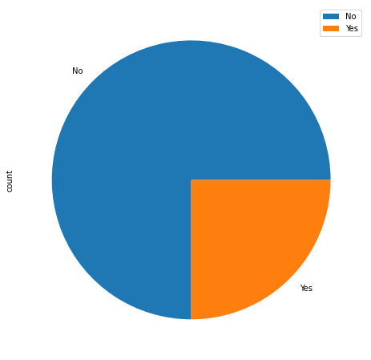

```python
print("\nRepresentation of Beard Attribute through Pai Chat for better Understanding: \n")
print(barView.groupby('beard').count().plot.pie(subplots=True, figsize=(8, 8)))
```

```
Representation of Scarf Attribute through Bar Chat for better Understanding:

AxesSubplot(0.125,0.125;0.775x0.755)
```

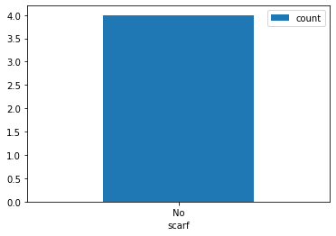

```python
barView = pd.DataFrame(testData.scarf)
barView["count"]= 0

print("\nRepresentation of Scarf Attribute through Bar Chat for better Understanding:  \n")
print(barView.groupby('scarf').count().plot.bar(rot=0))
```

```
Representation of Scarf Attribute through Pai Chat for better Understanding:

[<AxesSubplot:ylabel='count'>]
```

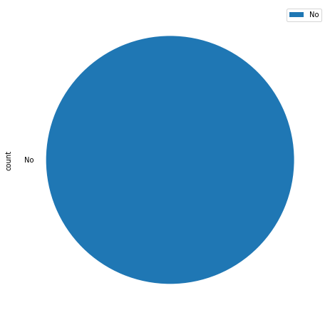

```python
print("\nRepresentation of Scarf Attribute through Pai Chat for better Understanding: \n")
print(barView.groupby('scarf').count().plot.pie(subplots=True, figsize=(8, 8)))
```

```
Representation of Height and Weight Attribute through Bar Chat for better Understanding:

AxesSubplot(0.125,0.125;0.775x0.755)
```

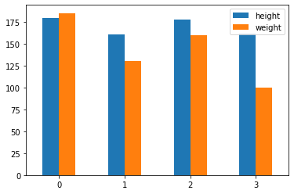

```python
barView = pd.DataFrame(testData[["height","weight"]])

print("\nRepresentation of Height and Weight Attribute through Bar Chat for better Understanding: \n")
print(barView.plot.bar(rot=0))
```

```
Representation of Height and Weight Attribute through Pai Chat for better Understanding:

[<AxesSubplot:ylabel='height'> <AxesSubplot:ylabel='weight'>]
```

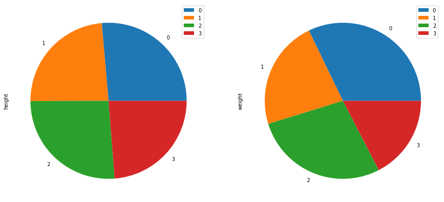

```python
print("\nRepresentation of Height and Weight Attribute through Pai Chat for better Understanding: \n")
print(barView.plot.pie(subplots=True, figsize=(15, 15)))
```

# Lable Encoding On Train Data

```
     After Analyzing data now we will do some PreProcessing operation on our train data and we will do lable encoding on
Categorical attribute.

    First we copy data in a new DataFrame:
```

```python
preProcessTrainData = trainData.copy()
preProcessTrainData
```

|  | height | weight | hair | beard | scarf | gender |
| --- | --- | --- | --- | --- | --- | --- |
| 0 | 180.30 | 196 | Bald | Yes | No | Male |
| 1 | 170.00 | 120 | Long | No | No | Female |
| 2 | 178.50 | 200 | Short | No | No | Male |
| 3 | 163.40 | 110 | Medium | No | Yes | Female |
| 4 | 175.22 | 220 | Short | Yes | No | Male |
| 5 | 165.00 | 150 | Medium | No | Yes | Female |

#### Create a Object for Lable Encoding of Gender Attribute. And than use fit_transform method and encode gender attribute in numaric form.

```python
leGender = preprocessing.LabelEncoder()

preProcessTrainData['gender'] = leGender.fit_transform(preProcessTrainData['gender'])
preProcessTrainData['gender']
```

```
0    1
1    0
2    1
3    0
4    1
5    0
Name: gender, dtype: int32
```

#### Create a Object for Lable Encoding of Scarf Attribute. And than use fit_transform method and encode Scarf attribute in numaric form.

```python
leScarf = preprocessing.LabelEncoder()

preProcessTrainData['scarf'] = leScarf.fit_transform(preProcessTrainData['scarf'])
preProcessTrainData['scarf']
```

```
0    0
1    0
2    0
3    1
4    0
5    1
Name: scarf, dtype: int32
```

#### Create a Object for Lable Encoding of Beard Attribute. And than use fit_transform method and encode Beard attribute in numaric form.

```python
leBeard = preprocessing.LabelEncoder()

preProcessTrainData['beard'] = leBeard.fit_transform(preProcessTrainData['beard'])
preProcessTrainData['beard']
```

```
0    1
1    0
2    0
3    0
4    1
5    0
Name: beard, dtype: int32
```

#### Create a Object for Lable Encoding of Hair Attribute. And than use fit_transform method and encode Hair attribute in numaric form.

```python
leHair = preprocessing.LabelEncoder()

preProcessTrainData['hair'] = leHair.fit_transform(preProcessTrainData['hair'])
preProcessTrainData['hair']
```

```
0    0
1    1
2    3
3    2
4    3
5    2
Name: hair, dtype: int32
```

#### After Lable Encoding our data will be look like:

```python
preProcessTrainData
```

|  | height | weight | hair | beard | scarf | gender |
| --- | --- | --- | --- | --- | --- | --- |
| 0 | 180.30 | 196 | 0 | 1 | 0 | 1 |
| 1 | 170.00 | 120 | 1 | 0 | 0 | 0 |
| 2 | 178.50 | 200 | 3 | 0 | 0 | 1 |
| 3 | 163.40 | 110 | 2 | 0 | 1 | 0 |
| 4 | 175.22 | 220 | 3 | 1 | 0 | 1 |
| 5 | 165.00 | 150 | 2 | 0 | 1 | 0 |

```python
# preProcessTrainData['gender'] = leGender.inverse_transform(preProcessTrainData['gender'])
# preProcessTrainData['scarf'] = leScarf.inverse_transform(preProcessTrainData['scarf'])
# preProcessTrainData['beard'] = leBeard.inverse_transform(preProcessTrainData['beard'])
# preProcessTrainData['hair'] = leHair.inverse_transform(preProcessTrainData['hair'])
#preProcessTrainData
```

# Lable Encoding On Test Data

```
     After Analyzing data now we will do some PreProcessing operation on our test data and we will do lable encoding on
Categorical attribute.

    First we copy data in a new DataFrame:
```

```python
preProcessTestData = testData.copy()
preProcessTestData
```

|  | height | weight | hair | beard | scarf | gender |
| --- | --- | --- | --- | --- | --- | --- |
| 0 | 179.10 | 185 | Long | Yes | No | Male |
| 1 | 160.50 | 130 | Short | No | No | Female |
| 2 | 177.80 | 160 | Bald | No | No | Male |
| 3 | 161.10 | 100 | Medium | No | No | Female |

#### We already Create a Object for Lable Encoding of Gender Attribute now use fit_transform method and encode gender attribute in numaric form.

```python
preProcessTestData['gender'] = leGender.fit_transform(preProcessTestData['gender'])
preProcessTestData['gender']
```

```
0    1
1    0
2    1
3    0
Name: gender, dtype: int32
```

#### We already Create a Object for Lable Encoding of Scarf Attribute now use fit_transform method and encode Scarf attribute in numaric form.

```python
preProcessTestData['scarf'] = leScarf.fit_transform(preProcessTestData['scarf'])
preProcessTestData['scarf']
```

```
0    0
1    0
2    0
3    0
Name: scarf, dtype: int32
```

#### We already Create a Object for Lable Encoding of Beard Attribute now use fit_transform method and encode Beard attribute in numaric form.

```python
preProcessTestData['beard'] = leBeard.fit_transform(preProcessTestData['beard'])
preProcessTestData['beard']
```

```
0    1
1    0
2    0
3    0
Name: beard, dtype: int32
```

#### We already Create a Object for Lable Encoding of Hair Attribute now use fit_transform method and encode Hair attribute in numaric form.

```python
preProcessTestData['hair'] = leHair.fit_transform(preProcessTestData['hair'])
preProcessTestData['hair']
```

```
0    1
1    3
2    0
3    2
Name: hair, dtype: int32
```

#### After Lable Encoding our data will be look like:

```python
preProcessTestData
```

|  | height | weight | hair | beard | scarf | gender |
| --- | --- | --- | --- | --- | --- | --- |
| 0 | 179.10 | 185 | 1 | 1 | 0 | 1 |
| 1 | 160.50 | 130 | 3 | 0 | 0 | 0 |
| 2 | 177.80 | 160 | 0 | 0 | 0 | 1 |
| 3 | 161.10 | 100 | 2 | 0 | 0 | 0 |

```python
# preProcessTestData['gender'] = leGender.inverse_transform(preProcessTestData['gender'])
# preProcessTestData['scarf'] = leScarf.inverse_transform(preProcessTestData['scarf'])
# preProcessTestData['beard'] = leBeard.inverse_transform(preProcessTestData['beard'])
# preProcessTestData['hair'] = leHair.inverse_transform(preProcessTestData['hair'])
# preProcessTestData
```

# Siplit Train Data

For model training siplit the input and output data in different variable for pass the model

```python
trainData_input = preProcessTrainData.iloc[:,:5]
trainData_input
```

|  | height | weight | hair | beard | scarf |
| --- | --- | --- | --- | --- | --- |
| 0 | 180.30 | 196 | 0 | 1 | 0 |
| 1 | 170.00 | 120 | 1 | 0 | 0 |
| 2 | 178.50 | 200 | 3 | 0 | 0 |
| 3 | 163.40 | 110 | 2 | 0 | 1 |
| 4 | 175.22 | 220 | 3 | 1 | 0 |
| 5 | 165.00 | 150 | 2 | 0 | 1 |

```python
trainData_output = preProcessTrainData.iloc[:,5]
trainData_output
```

```
0    1
1    0
2    1
3    0
4    1
5    0
Name: gender, dtype: int32
```

# Siplit Test Data

```python
testData_input = preProcessTestData.iloc[:,:5]
testData_input
```

|  | height | weight | hair | beard | scarf |
| --- | --- | --- | --- | --- | --- |
| 0 | 179.10 | 185 | 1 | 1 | 0 |
| 1 | 160.50 | 130 | 3 | 0 | 0 |
| 2 | 177.80 | 160 | 0 | 0 | 0 |
| 3 | 161.10 | 100 | 2 | 0 | 0 |

```python
testData_output = preProcessTestData.iloc[:,5]
testData_output
```

```
0    1
1    0
2    1
3    0
Name: gender, dtype: int32
```

# Pass Train Data and Train different Models

#### Impoet different Mechanic Learning Algorithm and give the training data and store input in a dictionady varibele name "prediction".

## Train ML Algo 1

```python
from sklearn.linear_model import LogisticRegression

liner = LogisticRegression()
liner.fit(trainData_input ,trainData_output)

prediction = { }
prediction["LogisticRegression"] =  liner.predict(testData_input)

print("Pridicted Output is : ", prediction["LogisticRegression"])
```

```
Pridicted Output is :  [1 0 0 0]
```

## Train ML Algo 2

```python
from sklearn.naive_bayes import BernoulliNB

bnb = BernoulliNB()
bnb.fit(trainData_input ,trainData_output)
prediction["BernoulliNB"] = bnb.predict(testData_input)

print("Pridicted Output is : ", prediction["BernoulliNB"])
```

```
Pridicted Output is :  [1 0 1 0]
```

## Train ML Algo 3

```python
from sklearn.ensemble import RandomForestClassifier

rfc = RandomForestClassifier()
rfc.fit(trainData_input ,trainData_output)
prediction["RandomForestClassifier"] = rfc.predict(testData_input)

print("Pridicted Output is : ", prediction["RandomForestClassifier"])
```

```
Pridicted Output is :  [1 0 1 0]
```

## Train ML Algo 4

```python
from sklearn.svm import LinearSVC

lsvc = LinearSVC()
lsvc.fit(trainData_input ,trainData_output)
prediction["LinearSVC"] = lsvc.predict(testData_input)

print("Pridicted Output is : ", prediction["LinearSVC"])
```

```
Pridicted Output is :  [1 0 0 0]
```

## Train ML Algo 5

```python
from sklearn.neighbors import KNeighborsClassifier

knbf = KNeighborsClassifier()
knbf.fit(trainData_input ,trainData_output)
prediction["KNeighborsClassifier"] = knbf.predict(testData_input)

print("Pridicted Output is : ", prediction["KNeighborsClassifier"])
```

```
Pridicted Output is :  [1 0 0 0]
```

## Train ML Algo 6

```python
from sklearn.tree import ExtraTreeClassifier

extTC = ExtraTreeClassifier()
extTC.fit(trainData_input ,trainData_output)
prediction["ExtraTreeClassifier"] = extTC.predict(testData_input)

print("Pridicted Output is : ", prediction["ExtraTreeClassifier"])
```

```
Pridicted Output is :  [1 0 1 0]
```

## Train ML Algo 7

```python
from sklearn.tree import DecisionTreeClassifier

decTC = DecisionTreeClassifier()
decTC.fit(trainData_input ,trainData_output)
prediction["DecisionTreeClassifier"] = decTC.predict(testData_input)

print("Pridicted Output is : ", prediction["DecisionTreeClassifier"])
```

```
Pridicted Output is :  [1 0 0 0]
```

## Train ML Algo 8

```python
from sklearn.neural_network import MLPClassifier

mlpc = MLPClassifier()
mlpc.fit(trainData_input ,trainData_output)
prediction["MLPClassifier"] = mlpc.predict(testData_input)

print("Pridicted Output is : ", prediction["MLPClassifier"])
```

```
Pridicted Output is :  [1 0 0 0]
```

## Train ML Algo 9

```python
from sklearn.ensemble import GradientBoostingClassifier

gbc = GradientBoostingClassifier()
gbc.fit(trainData_input ,trainData_output)
prediction["GradientBoostingClassifier"] = gbc.predict(testData_input)

print("Pridicted Output is : ", prediction["GradientBoostingClassifier"])
```

```
Pridicted Output is :  [1 0 1 0]
```

## Train ML Algo 10

```python
from sklearn.ensemble import BaggingClassifier

bagc = BaggingClassifier()
bagc.fit(trainData_input ,trainData_output)
prediction["BaggingClassifier"] = bagc.predict(testData_input)

print("Pridicted Output is : ", prediction["BaggingClassifier"])
```

```
Pridicted Output is :  [1 0 0 0]
```

## Train ML Algo 11

```python
from sklearn.ensemble import ExtraTreesClassifier

extc = ExtraTreesClassifier()
extc.fit(trainData_input ,trainData_output)
prediction["ExtraTreesClassifier"] = extc.predict(testData_input)

print("Pridicted Output is : ", prediction["ExtraTreesClassifier"])
```

```
Pridicted Output is :  [1 0 1 0]
```

## Train ML Algo 12

```python
from sklearn.linear_model import SGDClassifier

sgdc = SGDClassifier()
sgdc.fit(trainData_input ,trainData_output)
prediction["SGDClassifier"] = sgdc.predict(testData_input)

print("Pridicted Output is : ", prediction["SGDClassifier"])
```

```
Pridicted Output is :  [1 0 0 0]
```

## Train ML Algo 13

```python
from sklearn.linear_model import RidgeClassifierCV

ridcCV = RidgeClassifierCV()
ridcCV.fit(trainData_input ,trainData_output)
prediction["RidgeClassifierCV"] = ridcCV.predict(testData_input)

print("Pridicted Output is : ", prediction["RidgeClassifierCV"])
```

```
Pridicted Output is :  [1 0 1 0]
```

## Train ML Algo 14

```python
from sklearn.linear_model import RidgeClassifier

ridc = RidgeClassifier()
ridc.fit(trainData_input ,trainData_output)
prediction["RidgeClassifier"] = ridc.predict(testData_input)

print("Pridicted Output is : ", prediction["RidgeClassifier"])
```

```
Pridicted Output is :  [1 0 1 0]
```

## Train ML Algo 15

```python
from sklearn.linear_model import PassiveAggressiveClassifier

pac = PassiveAggressiveClassifier()
pac.fit(trainData_input ,trainData_output)
prediction["PassiveAggressiveClassifier"] = pac.predict(testData_input)

print("Pridicted Output is : ", prediction["PassiveAggressiveClassifier"])
```

```
Pridicted Output is :  [1 0 0 0]
```

## Train ML Algo 16

```python
from sklearn.gaussian_process import GaussianProcessClassifier

gpc = GaussianProcessClassifier()
gpc.fit(trainData_input ,trainData_output)
prediction["GaussianProcessClassifier"] = gpc.predict(testData_input)

print("Pridicted Output is : ", prediction["GaussianProcessClassifier"])
```

```
Pridicted Output is :  [1 0 0 0]
```

## Train ML Algo 17

```python
from sklearn.ensemble import AdaBoostClassifier

adbc = AdaBoostClassifier()
adbc.fit(trainData_input ,trainData_output)
prediction["AdaBoostClassifier"] = adbc.predict(testData_input)

print("Pridicted Output is : ", prediction["AdaBoostClassifier"])
```

```
Pridicted Output is :  [1 0 0 0]
```

## Train ML Algo 18

```python
from sklearn.naive_bayes import MultinomialNB

mnnb = MultinomialNB()
mnnb.fit(trainData_input ,trainData_output)
prediction["MultinomialNB"] = mnnb.predict(testData_input)

print("Pridicted Output is : ", prediction["MultinomialNB"])
```

```
Pridicted Output is :  [1 0 0 0]
```

## Train ML Algo 19

```python
from sklearn.neighbors import NearestCentroid

nc = NearestCentroid()
nc.fit(trainData_input ,trainData_output)
prediction["NearestCentroid"] = nc.predict(testData_input)

print("Pridicted Output is : ", prediction["NearestCentroid"])
```

```
Pridicted Output is :  [1 0 0 0]
```

## Train ML Algo 20

```python
from sklearn.svm import NuSVC

nsvc = NuSVC()
nsvc.fit(trainData_input ,trainData_output)
prediction["NuSVC"] = nsvc.predict(testData_input)

print("Pridicted Output is : ", prediction["NuSVC"])
```

```
Pridicted Output is :  [1 0 0 0]
```

## Train ML Algo 21

```python
from sklearn.linear_model import Perceptron

ccr = Perceptron()
ccr.fit(trainData_input ,trainData_output)
prediction["Perceptron"] = ccr.predict(testData_input)

print("Pridicted Output is : ", prediction["Perceptron"])
```

```
Pridicted Output is :  [0 0 0 0]
```

## Train ML Algo 22

```python
from sklearn.svm import SVC

svc = SVC()
svc.fit(trainData_input ,trainData_output)
prediction["SVC"] = svc.predict(testData_input)

print("Pridicted Output is : ", prediction["SVC"])
```

```
Pridicted Output is :  [1 0 0 0]
```

## Train ML Algo 23

```python
from sklearn.mixture import GaussianMixture

gm = GaussianMixture()
gm.fit(trainData_input ,trainData_output)
prediction["GaussianMixture"] = gm.predict(testData_input)

print("Pridicted Output is : ", prediction["GaussianMixture"])
```

```
Pridicted Output is :  [0 0 0 0]
```

## Train ML Algo 24

```python
from sklearn.discriminant_analysis import LinearDiscriminantAnalysis

lda = LinearDiscriminantAnalysis()
lda.fit(trainData_input ,trainData_output)
prediction["LinearDiscriminantAnalysisB"] = lda.predict(testData_input)

print("Pridicted Output is : ", prediction["LinearDiscriminantAnalysisB"])
```

```
Pridicted Output is :  [1 0 1 0]
```

## Train ML Algo 25

```python
from sklearn.naive_bayes import GaussianNB

gnb = GaussianNB()
gnb.fit(trainData_input ,trainData_output)
prediction["GaussianNB"] = gnb.predict(testData_input)

print("Pridicted Output is : ", prediction["GaussianNB"])
```

```
Pridicted Output is :  [1 0 1 0]
```

## Train ML Algo 26

```python
from sklearn.semi_supervised import LabelPropagation

lbp = LabelPropagation()
lbp.fit(trainData_input ,trainData_output)
prediction["LabelPropagation"] = lbp.predict(testData_input)

print("Pridicted Output is : ", prediction["LabelPropagation"])
```

```
Pridicted Output is :  [0 0 0 0]
```

## Train ML Algo 27

```python
from sklearn.semi_supervised import LabelSpreading

lbs = LabelSpreading()
lbs.fit(trainData_input ,trainData_output)
prediction["LabelSpreading"] = lbs.predict(testData_input)

print("Pridicted Output is : ", prediction["LabelSpreading"])
```

```
Pridicted Output is :  [0 0 0 0]
```

## Train ML Algo 28

```python
from sklearn.discriminant_analysis import QuadraticDiscriminantAnalysis

qda = QuadraticDiscriminantAnalysis()
qda.fit(trainData_input ,trainData_output)
prediction["QuadraticDiscriminantAnalysis"] = qda.predict(testData_input)

print("Pridicted Output is : ", prediction["QuadraticDiscriminantAnalysis"])
```

```
Pridicted Output is :  [1 0 0 0]
```

## Model Prediction

```
Import accuracy_score and mean_squared_error for measure the Prediction
```

```python
#from sklearn.metrics import accuracy_score
#from sklearn.metrics import mean_squared_error
```

## Create a Function for showing the all Predicted OutPut:

```python
def printPredictOutput(df,predict):
    cdf = df.copy()
    cdf["gender"] = predict

    cdf['gender'] = leGender.inverse_transform(cdf['gender'])
    cdf['scarf'] = leScarf.inverse_transform(cdf['scarf'])
    cdf['beard'] = leBeard.inverse_transform(cdf['beard'])
    cdf['hair'] = leHair.inverse_transform(cdf['hair'])
    print("\n", cdf)

    print("\nAccuracy Score is: {:.0%}".format(accuracy_score(testData_output, predict)))
    print("Mean Squared Error is: {:.0%}".format(mean_squared_error(testData_output, predict)))
```

## Create a Function for print Bold and color statement:

```python
#from IPython.display import Markdown, display

## function for show bold output
# def printmd(string):
#     display(Markdown(string))

# printmd('**bold**')

## function for show bold output with color
def printmd(string, color=None):
    colorstr = "<span style='color:{}'>{}</span>".format(color, string)
    display(Markdown(colorstr))
```

# Show all Predicted OutPut One by One

```python
count = 0
for x in prediction:
    count = count + 1
    print('\n')
    printmd('<b>{0}: Predicted OutPut of "{1}" Algorithm:</b>'.format(count ,x), color="blue")
    printPredictOutput(testData_input, prediction[x])
```

**1: Predicted OutPut of "LogisticRegression" Algorithm:**

```
    height  weight    hair beard scarf  gender
0  179.10     185    Long   Yes    No    Male
1  160.50     130   Short    No    No  Female
2  177.80     160    Bald    No    No  Female
3  161.10     100  Medium    No    No  Female

Accuracy Score is: 75%
Mean Squared Error is: 25%
```

**2: Predicted OutPut of "BernoulliNB" Algorithm:**

```
    height  weight    hair beard scarf  gender
0  179.10     185    Long   Yes    No    Male
1  160.50     130   Short    No    No  Female
2  177.80     160    Bald    No    No    Male
3  161.10     100  Medium    No    No  Female

Accuracy Score is: 100%
Mean Squared Error is: 0%
```

**3: Predicted OutPut of "RandomForestClassifier" Algorithm:**

```
    height  weight    hair beard scarf  gender
0  179.10     185    Long   Yes    No    Male
1  160.50     130   Short    No    No  Female
2  177.80     160    Bald    No    No    Male
3  161.10     100  Medium    No    No  Female

Accuracy Score is: 100%
Mean Squared Error is: 0%
```

**4: Predicted OutPut of "LinearSVC" Algorithm:**

```
    height  weight    hair beard scarf  gender
0  179.10     185    Long   Yes    No    Male
1  160.50     130   Short    No    No  Female
2  177.80     160    Bald    No    No  Female
3  161.10     100  Medium    No    No  Female

Accuracy Score is: 75%
Mean Squared Error is: 25%
```

**5: Predicted OutPut of "KNeighborsClassifier" Algorithm:**

```
    height  weight    hair beard scarf  gender
0  179.10     185    Long   Yes    No    Male
1  160.50     130   Short    No    No  Female
2  177.80     160    Bald    No    No  Female
3  161.10     100  Medium    No    No  Female

Accuracy Score is: 75%
Mean Squared Error is: 25%
```

**6: Predicted OutPut of "ExtraTreeClassifier" Algorithm:**

```
    height  weight    hair beard scarf  gender
0  179.10     185    Long   Yes    No    Male
1  160.50     130   Short    No    No  Female
2  177.80     160    Bald    No    No    Male
3  161.10     100  Medium    No    No  Female

Accuracy Score is: 100%
Mean Squared Error is: 0%
```

**7: Predicted OutPut of "DecisionTreeClassifier" Algorithm:**

```
    height  weight    hair beard scarf  gender
0  179.10     185    Long   Yes    No    Male
1  160.50     130   Short    No    No  Female
2  177.80     160    Bald    No    No  Female
3  161.10     100  Medium    No    No  Female

Accuracy Score is: 75%
Mean Squared Error is: 25%
```

**8: Predicted OutPut of "MLPClassifier" Algorithm:**

```
    height  weight    hair beard scarf  gender
0  179.10     185    Long   Yes    No    Male
1  160.50     130   Short    No    No  Female
2  177.80     160    Bald    No    No  Female
3  161.10     100  Medium    No    No  Female

Accuracy Score is: 75%
Mean Squared Error is: 25%
```

**9: Predicted OutPut of "GradientBoostingClassifier" Algorithm:**

```
    height  weight    hair beard scarf  gender
0  179.10     185    Long   Yes    No    Male
1  160.50     130   Short    No    No  Female
2  177.80     160    Bald    No    No    Male
3  161.10     100  Medium    No    No  Female

Accuracy Score is: 100%
Mean Squared Error is: 0%
```

**10: Predicted OutPut of "BaggingClassifier" Algorithm:**

```
    height  weight    hair beard scarf  gender
0  179.10     185    Long   Yes    No    Male
1  160.50     130   Short    No    No  Female
2  177.80     160    Bald    No    No  Female
3  161.10     100  Medium    No    No  Female

Accuracy Score is: 75%
Mean Squared Error is: 25%
```

**11: Predicted OutPut of "ExtraTreesClassifier" Algorithm:**

```
    height  weight    hair beard scarf  gender
0  179.10     185    Long   Yes    No    Male
1  160.50     130   Short    No    No  Female
2  177.80     160    Bald    No    No    Male
3  161.10     100  Medium    No    No  Female

Accuracy Score is: 100%
Mean Squared Error is: 0%
```

**12: Predicted OutPut of "SGDClassifier" Algorithm:**

```
    height  weight    hair beard scarf  gender
0  179.10     185    Long   Yes    No    Male
1  160.50     130   Short    No    No  Female
2  177.80     160    Bald    No    No  Female
3  161.10     100  Medium    No    No  Female

Accuracy Score is: 75%
Mean Squared Error is: 25%
```

**13: Predicted OutPut of "RidgeClassifierCV" Algorithm:**

```
    height  weight    hair beard scarf  gender
0  179.10     185    Long   Yes    No    Male
1  160.50     130   Short    No    No  Female
2  177.80     160    Bald    No    No    Male
3  161.10     100  Medium    No    No  Female

Accuracy Score is: 100%
Mean Squared Error is: 0%
```

**14: Predicted OutPut of "RidgeClassifier" Algorithm:**

```
    height  weight    hair beard scarf  gender
0  179.10     185    Long   Yes    No    Male
1  160.50     130   Short    No    No  Female
2  177.80     160    Bald    No    No    Male
3  161.10     100  Medium    No    No  Female

Accuracy Score is: 100%
Mean Squared Error is: 0%
```

**15: Predicted OutPut of "PassiveAggressiveClassifier" Algorithm:**

```
    height  weight    hair beard scarf  gender
0  179.10     185    Long   Yes    No    Male
1  160.50     130   Short    No    No  Female
2  177.80     160    Bald    No    No  Female
3  161.10     100  Medium    No    No  Female

Accuracy Score is: 75%
Mean Squared Error is: 25%
```

**16: Predicted OutPut of "GaussianProcessClassifier" Algorithm:**

```
    height  weight    hair beard scarf  gender
0  179.10     185    Long   Yes    No    Male
1  160.50     130   Short    No    No  Female
2  177.80     160    Bald    No    No  Female
3  161.10     100  Medium    No    No  Female

Accuracy Score is: 75%
Mean Squared Error is: 25%
```

**17: Predicted OutPut of "AdaBoostClassifier" Algorithm:**

```
    height  weight    hair beard scarf  gender
0  179.10     185    Long   Yes    No    Male
1  160.50     130   Short    No    No  Female
2  177.80     160    Bald    No    No  Female
3  161.10     100  Medium    No    No  Female

Accuracy Score is: 75%
Mean Squared Error is: 25%
```

**18: Predicted OutPut of "MultinomialNB" Algorithm:**

```
    height  weight    hair beard scarf  gender
0  179.10     185    Long   Yes    No    Male
1  160.50     130   Short    No    No  Female
2  177.80     160    Bald    No    No  Female
3  161.10     100  Medium    No    No  Female

Accuracy Score is: 75%
Mean Squared Error is: 25%
```

**19: Predicted OutPut of "NearestCentroid" Algorithm:**

```
    height  weight    hair beard scarf  gender
0  179.10     185    Long   Yes    No    Male
1  160.50     130   Short    No    No  Female
2  177.80     160    Bald    No    No  Female
3  161.10     100  Medium    No    No  Female

Accuracy Score is: 75%
Mean Squared Error is: 25%
```

**20: Predicted OutPut of "NuSVC" Algorithm:**

```
    height  weight    hair beard scarf  gender
0  179.10     185    Long   Yes    No    Male
1  160.50     130   Short    No    No  Female
2  177.80     160    Bald    No    No  Female
3  161.10     100  Medium    No    No  Female

Accuracy Score is: 75%
Mean Squared Error is: 25%
```

**21: Predicted OutPut of "Perceptron" Algorithm:**

```
    height  weight    hair beard scarf  gender
0  179.10     185    Long   Yes    No  Female
1  160.50     130   Short    No    No  Female
2  177.80     160    Bald    No    No  Female
3  161.10     100  Medium    No    No  Female

Accuracy Score is: 50%
Mean Squared Error is: 50%
```

**22: Predicted OutPut of "SVC" Algorithm:**

```
    height  weight    hair beard scarf  gender
0  179.10     185    Long   Yes    No    Male
1  160.50     130   Short    No    No  Female
2  177.80     160    Bald    No    No  Female
3  161.10     100  Medium    No    No  Female

Accuracy Score is: 75%
Mean Squared Error is: 25%
```

**23: Predicted OutPut of "GaussianMixture" Algorithm:**

```
    height  weight    hair beard scarf  gender
0  179.10     185    Long   Yes    No  Female
1  160.50     130   Short    No    No  Female
2  177.80     160    Bald    No    No  Female
3  161.10     100  Medium    No    No  Female

Accuracy Score is: 50%
Mean Squared Error is: 50%
```

**24: Predicted OutPut of "LinearDiscriminantAnalysisB" Algorithm:**

```
    height  weight    hair beard scarf  gender
0  179.10     185    Long   Yes    No    Male
1  160.50     130   Short    No    No  Female
2  177.80     160    Bald    No    No    Male
3  161.10     100  Medium    No    No  Female

Accuracy Score is: 100%
Mean Squared Error is: 0%
```

**25: Predicted OutPut of "GaussianNB" Algorithm:**

```
    height  weight    hair beard scarf  gender
0  179.10     185    Long   Yes    No    Male
1  160.50     130   Short    No    No  Female
2  177.80     160    Bald    No    No    Male
3  161.10     100  Medium    No    No  Female

Accuracy Score is: 100%
Mean Squared Error is: 0%
```

**26: Predicted OutPut of "LabelPropagation" Algorithm:**

```
    height  weight    hair beard scarf  gender
0  179.10     185    Long   Yes    No  Female
1  160.50     130   Short    No    No  Female
2  177.80     160    Bald    No    No  Female
3  161.10     100  Medium    No    No  Female

Accuracy Score is: 50%
Mean Squared Error is: 50%
```

**27: Predicted OutPut of "LabelSpreading" Algorithm:**

```
    height  weight    hair beard scarf  gender
0  179.10     185    Long   Yes    No  Female
1  160.50     130   Short    No    No  Female
2  177.80     160    Bald    No    No  Female
3  161.10     100  Medium    No    No  Female

Accuracy Score is: 50%
Mean Squared Error is: 50%
```

**28: Predicted OutPut of "QuadraticDiscriminantAnalysis" Algorithm:**

```
    height  weight    hair beard scarf  gender
0  179.10     185    Long   Yes    No    Male
1  160.50     130   Short    No    No  Female
2  177.80     160    Bald    No    No  Female
3  161.10     100  Medium    No    No  Female

Accuracy Score is: 75%
Mean Squared Error is: 25%
```

# Show all Predicted OutPut Through Bar Chat

**1: Predicted OutPut of "LogisticRegression" Algorithm:**

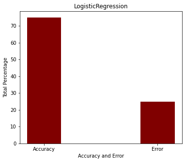

**2: Predicted OutPut of "BernoulliNB" Algorithm:**

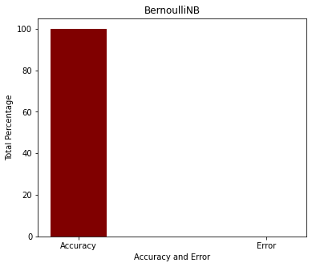

**3: Predicted OutPut of "RandomForestClassifier" Algorithm:**

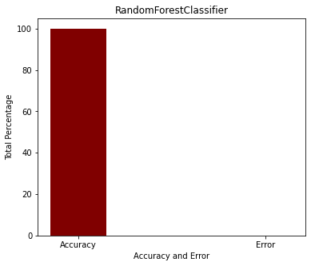

**4: Predicted OutPut of "LinearSVC" Algorithm:**

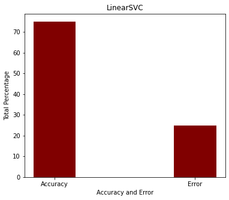

**5: Predicted OutPut of "KNeighborsClassifier" Algorithm:**

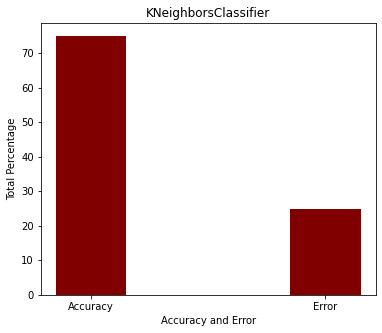

**6: Predicted OutPut of "ExtraTreeClassifier" Algorithm:**

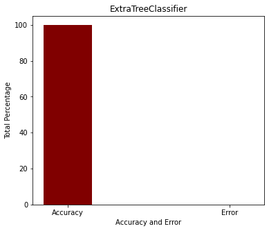

**7: Predicted OutPut of "DecisionTreeClassifier" Algorithm:**

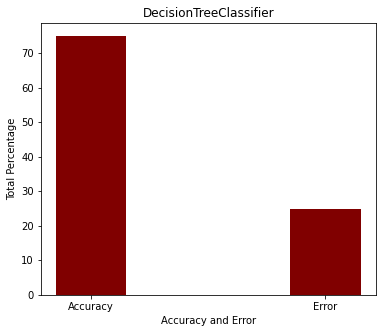

**8: Predicted OutPut of "MLPClassifier" Algorithm:**

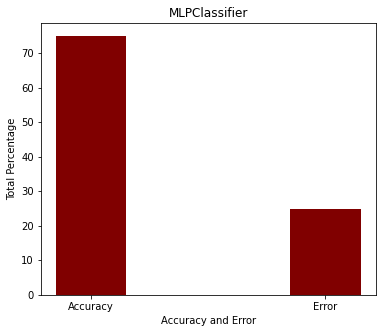

**9: Predicted OutPut of "GradientBoostingClassifier" Algorithm:**

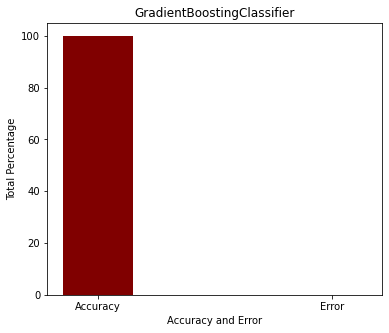

**10: Predicted OutPut of "BaggingClassifier" Algorithm:**

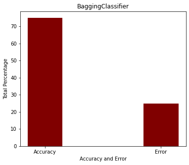

**11: Predicted OutPut of "ExtraTreesClassifier" Algorithm:**

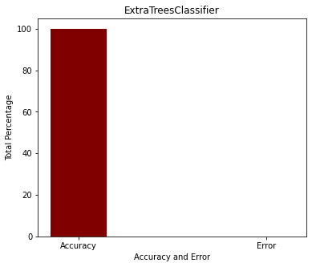

**12: Predicted OutPut of "SGDClassifier" Algorithm:**

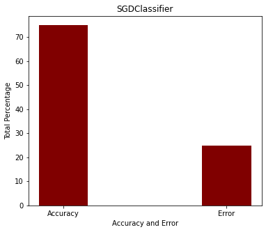

**13: Predicted OutPut of "RidgeClassifierCV" Algorithm:**

[16 more figures not shown]

```python
# Define a Function for showing tha Bar Chat of each Model
def printPredictBarChat(title, predict):
    lable = ["Accuracy","Error"]
    values = [ (100 * accuracy_score(testData_output, predict)),(100 * mean_squared_error(testData_output, predict))]

    fig = plt.figure(figsize = (6, 5))
    plt.bar(lable, values, color ='maroon', width = 0.3)

    plt.xlabel("Accuracy and Error")
    plt.ylabel("Total Percentage")
    plt.title(title)

    plt.show()



# Call Function through loop
count = 0
for x in prediction:
    count = count + 1
    print('\n')
    printmd('<b>{0}: Predicted OutPut of "{1}" Algorithm:</b>'.format(count ,x), color="blue")
    printPredictBarChat(x, prediction[x])
```